# Mi primer R Markdown

Módulo 3

CA FMAT & CEFMAT

17 de febrero del 2021

# R Markdown

## Markdown

- Es un lenguaje de marcado

# Título

## Subtítulo

### Sub-Subtpitulo

$\vdots$

$\dfrac{2}{3}$

$$\int_0^xf(t)\ dt$$

- Para ejecutar un R Markdown (generar un output), debemos hacer click donde dice “Knit”, o presionar `CTRL o CMD + SHIFT + K`
- Esto está escrito en *cursiva*.
- Esto esta escrito en **negrita**.
- Accedamos al siguiente [link](https://www.google.cl).
- Esto tiene apariencia de `codigo`.
- Con el asterisco (*) puedo hacer una viñeta.
1. Texto a
2. Texto b
3. Texto c

### Tablas

- Se hacen con guiones medios y barras varticales (|)

| Edad | Estatura |
| --- | --- |
| 40 | 189 |
| 45 | 140 |

### Chunks

```r
print(paste("Esto es un código de R"))
```

```
## [1] "Esto es un cÃ³digo de R"
```

```r
for (i in 1:2) {
    print(i)
}
```

```
## [1] 1
## [1] 2
```

```python
print("Esto es código en Python")
```

```
## Esto es código en Python
```

```python
for i in range(1, 3):
    print(i)
```

```
## 1
## 2
```

```r
library(datasets)
data("economics")
```

- echo: cuando es FALSE, output pero no código
- include: cuando es FALSE, ni código ni output.
- result: cuando es FALSE, muestra el código pero no resultado
- message: cuando es FALSE, no muestra mensajes asociados al código.
- warning: cuando es FALSE, no muestra advertencias
- error: cuando es FALSE, no muestra errores (solo no muestra mensaje de error)
- fig.align: Puede ser “right”, “left” o “center”.

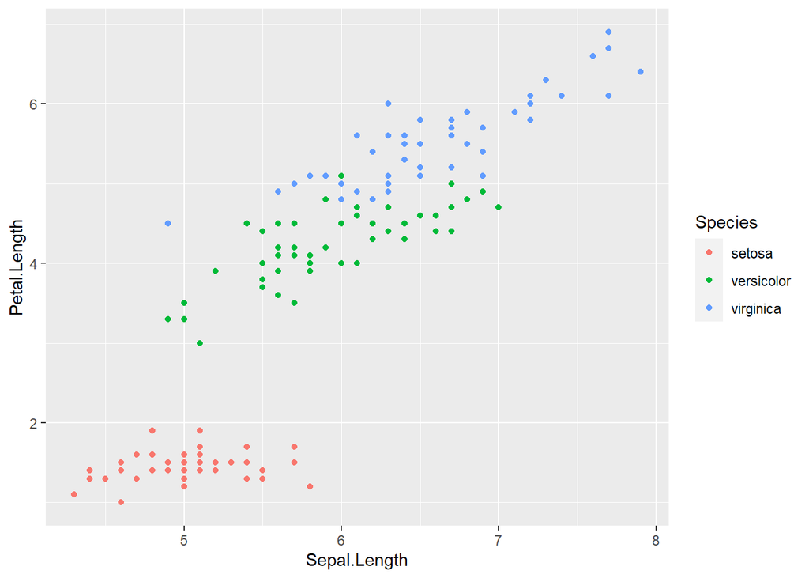

El resultado de la media entre 3, 4 y 5 es: `4`.

```r
variable <- mean(c(3, 4, 5))
```

El resultado de la media entre 3, 4 y 5 es: `4`.

```r
data <- import(here::here("datos-sin-procesar", "owid-covid-data.csv"))
```

```r
chile_arg_peru <- data %>%
    filter(location %in% c("Chile", "Argentina", "Peru")) %>%
    filter(date >= "2021-01-01" & date <= "2021-01-31") %>%
    filter(!is.na(new_cases)) %>%
    select(location, date, new_cases) %>%
    group_by(location) %>%
    summarize(media_casos = mean(new_cases),
              suma_casos = sum(new_cases)) %>%
    arrange(desc(media_casos))

chile_arg_peru
```

```
## # A tibble: 3 x 3
##   location  media_casos suma_casos
##   <chr>           <dbl>      <dbl>
## 1 Argentina       9733.     301725
## 2 Peru            3971.     123102
## 3 Chile           3811.     118136
```

Ahora usamos package DT:

```r
# install.packages("DT")
# require(DT)
chile_arg_peru %>%
    datatable
```

|  | location | media_casos | suma_casos |
| --- | --- | --- | --- |
| 1 | Argentina | 9733.06451612903 | 301725 |
| 2 | Peru | 3971.03225806452 | 123102 |
| 3 | Chile | 3810.83870967742 | 118136 |

- Si usamos un output en formato pdf:

```r
# install.packages("knitr")
# require(knitr)

chile_arg_peru %>%
    kable()
```

| location | media_casos | suma_casos |
| --- | --- | --- |
| Argentina | 9733.065 | 301725 |
| Peru | 3971.032 | 123102 |
| Chile | 3810.839 | 118136 |

### Imágenes

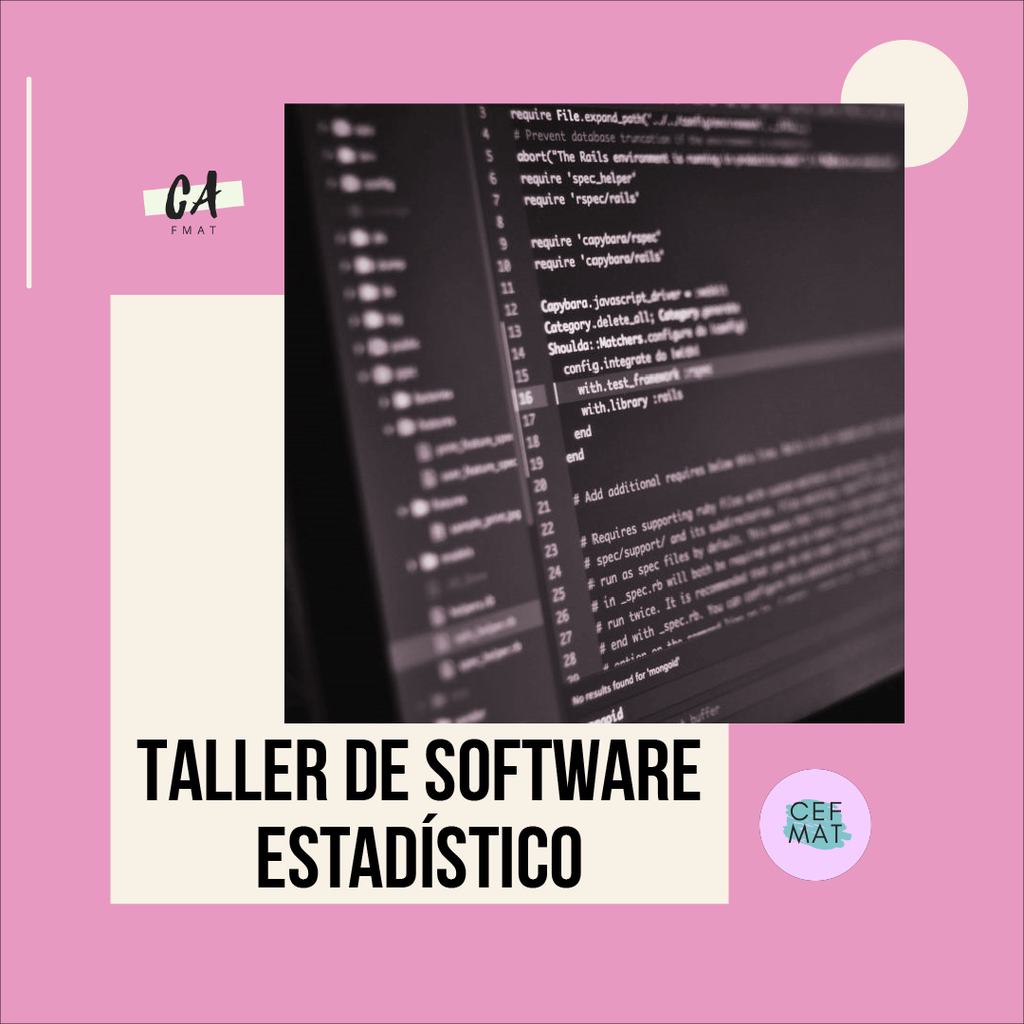

```r
# require(knitr)

include_graphics(here::here("imagenes", "1.jpg"))
```